# Matrix Alpha // Firestarter SPB

## Firestarter-Style Top 100 Multi-Panel Chart Viewer

### How to Run the Notebook:

1. In the Jupyter menu bar, click **Run** -> **Run All Cells**.
2. Scroll down to see the rendered inventory table, statistical analysis, and 4-panel visual charts.

> **[IMPORTANT] WARNINGS & CONSTRAINTS**
> - **Research Viewer Only:** This notebook is strictly for offline inspection, profiling, and quality validation of the ingested dataset.
> - **No Cell 2 / Labels:** This notebook does not generate target labels, features, or predictive variables.
> - **No Model Training:** There is no machine learning model training or parameter optimization here.
> - **No Trading Recommendations / Strategy Claims:** This notebook does not contain any trading strategies, execution logic, or financial recommendations.
> - **No ER / FMLC / Flowprint Computation:** No custom volatility or flow-based indicator calculation is performed in this version.

```python
import os
import glob
import json
import pandas as pd
import numpy as np
import matplotlib.pyplot as plt
from datetime import datetime, timezone

# Ensure charts render inline
%matplotlib inline

# Set styling for premium visual feel
plt.style.use('seaborn-v0_8-whitegrid' if 'seaborn-v0_8-whitegrid' in plt.style.available else 'default')
plt.rcParams['figure.figsize'] = (14, 16)
plt.rcParams['font.size'] = 10
plt.rcParams['axes.edgecolor'] = '#CCCCCC'
plt.rcParams['axes.linewidth'] = 0.8

# Dataset Path
DATA_DIR = "../data/research/binance_top100_excluding_existing_5_1month"
print(f"Dataset target path configured: {DATA_DIR}")
```

```
Dataset target path configured: ../data/research/binance_top100_excluding_existing_5_1month
```

### Symbol and Date Range Selection

**Instruction:** To analyze a different symbol or time slice:

1. Update the `SELECTED_SYMBOL` variable to any valid ticker.
2. Customize `START_DATE` and `END_DATE` (format: `'YYYY-MM-DD'`) or leave as `None` to inspect the full range.
3. Run the cells below.

```python
# UPDATE THESE VARIABLES FOR CUSTOM SLICING
SELECTED_SYMBOL = "BTCUSDT"
START_DATE = None  # e.g., "2026-06-01"
END_DATE = None    # e.g., "2026-06-07"

print(f"Selected Ticker: {SELECTED_SYMBOL}")
print(f"Custom Window: Start={START_DATE}, End={END_DATE}")
```

```
Selected Ticker: BTCUSDT
Custom Window: Start=None, End=None
```

### Section 1: Ingested Dataset Inventory Audit

We scan the target directory to verify the data integrity of all 100 symbols.

```python
def build_inventory(data_dir):
    csv_files = glob.glob(os.path.join(data_dir, "*_1month_5m.csv"))
    inventory = []

    for filepath in csv_files:
        filename = os.path.basename(filepath)
        symbol = filename.replace("_1month_5m.csv", "")

        try:
            df_temp = pd.read_csv(filepath)
            row_count = len(df_temp)

            if row_count > 0:
                first_ts = int(df_temp.iloc[0]['open_time'])
                last_ts = int(df_temp.iloc[-1]['open_time'])

                expected_span_count = int((last_ts - first_ts) / 300000) + 1
                missing_5m = max(0, expected_span_count - row_count)

                first_dt = pd.to_datetime(first_ts, unit='ms', utc=True).strftime('%Y-%m-%d %H:%M:%S')
                last_dt = pd.to_datetime(last_ts, unit='ms', utc=True).strftime('%Y-%m-%d %H:%M:%S')
            else:
                first_ts, last_ts = np.nan, np.nan
                first_dt, last_dt = "N/A", "N/A"
                missing_5m = 0

            nonstandard_flag = not symbol.isascii()

            inventory.append({
                "symbol": symbol,
                "row_count": row_count,
                "first_timestamp": first_ts,
                "last_timestamp": last_ts,
                "first_time_utc": first_dt,
                "last_time_utc": last_dt,
                "missing_5m_count": missing_5m,
                "nonstandard_symbol_flag": nonstandard_flag
            })
        except Exception as e:
            print(f"Error reading {symbol}: {e}")

    df_inv = pd.DataFrame(inventory)
    if not df_inv.empty:
        df_inv = df_inv.sort_values(by="symbol")
    return df_inv

df_inventory = build_inventory(DATA_DIR)
print(f"Loaded metadata for {len(df_inventory)} symbols.")

# Check for non-standard symbols and trigger warning flag
nonstandard_symbols = df_inventory[df_inventory['nonstandard_symbol_flag'] == True]['symbol'].tolist()
if nonstandard_symbols:
    print(f"\n[WARNING] Non-standard Unicode tickers detected in dataset: {nonstandard_symbols}")

df_inventory
```

```
Loaded metadata for 100 symbols.

[WARNING] Non-standard Unicode tickers detected in dataset: ['币安人生USDT', '龙虾USDT']
```

|  | symbol | row_count | first_timestamp | last_timestamp | first_time_utc | last_time_utc | missing_5m_count | nonstandard_symbol_flag |
| --- | --- | --- | --- | --- | --- | --- | --- | --- |
| 0 | 1000BONKUSDT | 8640 | 1778268000000 | 1780859700000 | 2026-05-08 19:20:00 | 2026-06-07 19:15:00 | 0 | False |
| 1 | 1000LUNCUSDT | 8640 | 1778268000000 | 1780859700000 | 2026-05-08 19:20:00 | 2026-06-07 19:15:00 | 0 | False |
| 2 | 1000PEPEUSDT | 8640 | 1778267700000 | 1780859400000 | 2026-05-08 19:15:00 | 2026-06-07 19:10:00 | 0 | False |
| 3 | 1000SHIBUSDT | 8640 | 1778267700000 | 1780859400000 | 2026-05-08 19:15:00 | 2026-06-07 19:10:00 | 0 | False |
| 4 | AAVEUSDT | 8640 | 1778267700000 | 1780859400000 | 2026-05-08 19:15:00 | 2026-06-07 19:10:00 | 0 | False |
| ... | ... | ... | ... | ... | ... | ... | ... | ... |
| 95 | XPLUSDT | 8640 | 1778267700000 | 1780859400000 | 2026-05-08 19:15:00 | 2026-06-07 19:10:00 | 0 | False |
| 96 | ZECUSDT | 8640 | 1778267700000 | 1780859400000 | 2026-05-08 19:15:00 | 2026-06-07 19:10:00 | 0 | False |
| 97 | ZESTUSDT | 927 | 1780581600000 | 1780859400000 | 2026-06-04 14:00:00 | 2026-06-07 19:10:00 | 0 | False |
| 98 | 币安人生USDT | 8640 | 1778267700000 | 1780859400000 | 2026-05-08 19:15:00 | 2026-06-07 19:10:00 | 0 | True |
| 99 | 龙虾USDT | 8640 | 1778267700000 | 1780859400000 | 2026-05-08 19:15:00 | 2026-06-07 19:10:00 | 0 | True |

100 rows × 8 columns

### Section 2: Selected Symbol Detailed Profiling & Data Loading

```python
csv_path = os.path.join(DATA_DIR, f"{SELECTED_SYMBOL}_1month_5m.csv")
if not os.path.exists(csv_path):
    files = glob.glob(os.path.join(DATA_DIR, f"*{SELECTED_SYMBOL}*_5m.csv"))
    if files:
        csv_path = files[0]
        print(f"Resolved non-standard path: {csv_path}")
    else:
        raise FileNotFoundError(f"No CSV found for: {SELECTED_SYMBOL}")

df = pd.read_csv(csv_path)
df['open_datetime'] = pd.to_datetime(df['open_time'], unit='ms', utc=True)
df['close_datetime'] = pd.to_datetime(df['close_time'], unit='ms', utc=True)

# Slicing time window if configured
if START_DATE:
    df = df[df['open_datetime'] >= pd.to_datetime(START_DATE, utc=True)]
if END_DATE:
    df = df[df['open_datetime'] <= pd.to_datetime(END_DATE, utc=True)]

print(f"Successfully loaded {len(df)} rows for {SELECTED_SYMBOL}")
if not SELECTED_SYMBOL.isascii():
    print("[WARNING] This symbol contains nonstandard unicode characters. Handle encoding safely.")

print("\n--- Latest 20 Rows Preview ---")
df.tail(20)
```

```
Successfully loaded 8640 rows for BTCUSDT

--- Latest 20 Rows Preview ---
```

|  | open_time | open | high | low | close | volume | close_time | quote_asset_volume | trades | taker_buy_base | taker_buy_quote | ignore | open_datetime | close_datetime |
| --- | --- | --- | --- | --- | --- | --- | --- | --- | --- | --- | --- | --- | --- | --- |
| 8620 | 1780853700000 | 62228.9 | 62289.5 | 62214.9 | 62228.0 | 216.336 | 1780853999999 | 1.346861e+07 | 10455 | 112.396 | 6.997419e+06 | 0 | 2026-06-07 17:35:00+00:00 | 2026-06-07 17:39:59.999000+00:00 |
| 8621 | 1780854000000 | 62228.0 | 62315.6 | 62195.2 | 62238.2 | 476.226 | 1780854299999 | 2.964819e+07 | 11245 | 322.700 | 2.009177e+07 | 0 | 2026-06-07 17:40:00+00:00 | 2026-06-07 17:44:59.999000+00:00 |
| 8622 | 1780854300000 | 62238.3 | 62238.3 | 62065.5 | 62198.7 | 567.978 | 1780854599999 | 3.529091e+07 | 15004 | 184.640 | 1.147449e+07 | 0 | 2026-06-07 17:45:00+00:00 | 2026-06-07 17:49:59.999000+00:00 |
| 8623 | 1780854600000 | 62198.7 | 62200.0 | 62061.6 | 62145.1 | 357.749 | 1780854899999 | 2.222201e+07 | 10476 | 110.731 | 6.878958e+06 | 0 | 2026-06-07 17:50:00+00:00 | 2026-06-07 17:54:59.999000+00:00 |
| 8624 | 1780854900000 | 62145.1 | 62174.6 | 62121.0 | 62129.6 | 90.632 | 1780855199999 | 5.631947e+06 | 4524 | 41.047 | 2.550505e+06 | 0 | 2026-06-07 17:55:00+00:00 | 2026-06-07 17:59:59.999000+00:00 |
| 8625 | 1780855200000 | 62129.6 | 62218.5 | 62120.4 | 62120.4 | 189.445 | 1780855499999 | 1.177711e+07 | 8890 | 107.797 | 6.701477e+06 | 0 | 2026-06-07 18:00:00+00:00 | 2026-06-07 18:04:59.999000+00:00 |
| 8626 | 1780855500000 | 62120.5 | 62209.4 | 62120.5 | 62188.5 | 116.996 | 1780855799999 | 7.274224e+06 | 6960 | 65.622 | 4.079868e+06 | 0 | 2026-06-07 18:05:00+00:00 | 2026-06-07 18:09:59.999000+00:00 |
| 8627 | 1780855800000 | 62188.4 | 62267.2 | 62169.9 | 62246.9 | 126.680 | 1780856099999 | 7.881378e+06 | 7102 | 78.432 | 4.879755e+06 | 0 | 2026-06-07 18:10:00+00:00 | 2026-06-07 18:14:59.999000+00:00 |
| 8628 | 1780856100000 | 62246.9 | 62246.9 | 62107.4 | 62131.6 | 180.479 | 1780856399999 | 1.121667e+07 | 8052 | 74.219 | 4.611699e+06 | 0 | 2026-06-07 18:15:00+00:00 | 2026-06-07 18:19:59.999000+00:00 |
| 8629 | 1780856400000 | 62131.7 | 62190.0 | 62131.6 | 62169.1 | 101.693 | 1780856699999 | 6.321427e+06 | 5735 | 53.897 | 3.350189e+06 | 0 | 2026-06-07 18:20:00+00:00 | 2026-06-07 18:24:59.999000+00:00 |
| 8630 | 1780856700000 | 62169.1 | 62208.6 | 62156.8 | 62196.0 | 73.647 | 1780856999999 | 4.579740e+06 | 3963 | 41.833 | 2.601385e+06 | 0 | 2026-06-07 18:25:00+00:00 | 2026-06-07 18:29:59.999000+00:00 |
| 8631 | 1780857000000 | 62196.0 | 62266.0 | 62178.0 | 62201.1 | 166.803 | 1780857299999 | 1.037910e+07 | 8500 | 89.937 | 5.596299e+06 | 0 | 2026-06-07 18:30:00+00:00 | 2026-06-07 18:34:59.999000+00:00 |
| 8632 | 1780857300000 | 62201.1 | 62225.0 | 62130.1 | 62172.1 | 219.691 | 1780857599999 | 1.365988e+07 | 8728 | 95.465 | 5.935292e+06 | 0 | 2026-06-07 18:35:00+00:00 | 2026-06-07 18:39:59.999000+00:00 |
| 8633 | 1780857600000 | 62172.1 | 62183.9 | 62142.7 | 62173.0 | 56.176 | 1780857899999 | 3.492173e+06 | 3892 | 28.141 | 1.749297e+06 | 0 | 2026-06-07 18:40:00+00:00 | 2026-06-07 18:44:59.999000+00:00 |
| 8634 | 1780857900000 | 62173.1 | 62208.4 | 62088.0 | 62093.0 | 111.718 | 1780858199999 | 6.943619e+06 | 5939 | 46.826 | 2.910471e+06 | 0 | 2026-06-07 18:45:00+00:00 | 2026-06-07 18:49:59.999000+00:00 |
| 8635 | 1780858200000 | 62093.0 | 62101.2 | 62028.0 | 62081.9 | 292.074 | 1780858499999 | 1.812675e+07 | 9746 | 104.085 | 6.459387e+06 | 0 | 2026-06-07 18:50:00+00:00 | 2026-06-07 18:54:59.999000+00:00 |
| 8636 | 1780858500000 | 62082.0 | 62126.5 | 61989.0 | 62001.6 | 444.597 | 1780858799999 | 2.758865e+07 | 9970 | 190.981 | 1.185135e+07 | 0 | 2026-06-07 18:55:00+00:00 | 2026-06-07 18:59:59.999000+00:00 |
| 8637 | 1780858800000 | 62001.6 | 62009.1 | 61657.9 | 61825.8 | 2219.154 | 1780859099999 | 1.371647e+08 | 48633 | 734.959 | 4.542148e+07 | 0 | 2026-06-07 19:00:00+00:00 | 2026-06-07 19:04:59.999000+00:00 |
| 8638 | 1780859100000 | 61825.9 | 61825.9 | 61538.1 | 61555.2 | 1497.955 | 1780859399999 | 9.232832e+07 | 36430 | 596.740 | 3.678068e+07 | 0 | 2026-06-07 19:05:00+00:00 | 2026-06-07 19:09:59.999000+00:00 |
| 8639 | 1780859400000 | 61555.1 | 61694.5 | 61550.2 | 61680.3 | 270.255 | 1780859699999 | 1.665177e+07 | 9220 | 166.153 | 1.023847e+07 | 0 | 2026-06-07 19:10:00+00:00 | 2026-06-07 19:14:59.999000+00:00 |

### Section 3: Numeric Summary Statistics & Volatility Slicing

```python
print("--- OHLCV Numeric Stats ---")
print(df[['open', 'high', 'low', 'close', 'volume']].describe())

df['candle_range'] = df['high'] - df['low']
df['range_pct'] = (df['candle_range'] / df['open']) * 100

print("\n--- Volatility and Volume Analysis ---")
vol_stats = {
    "Total Volume (Base)": df['volume'].sum(),
    "Average Volume/Candle": df['volume'].mean(),
    "Max Volume/Candle": df['volume'].max(),
    "Mean Candle Range (USDT)": df['candle_range'].mean(),
    "Mean Candle Range (% of Open)": df['range_pct'].mean(),
    "Max Candle Range (% of Open)": df['range_pct'].max(),
}
for k, v in vol_stats.items():
    print(f"{k}: {v:,.4f}")
```

```
--- OHLCV Numeric Stats ---
               open          high           low         close        volume
count   8640.000000   8640.000000   8640.000000   8640.000000   8640.000000
mean   74726.880266  74782.571065  74667.435718  74724.757697    560.233885
std     5929.808816   5910.532114   5950.721901   5931.194395    855.824813
min    59170.000000  59383.500000  59080.000000  59170.000000     21.526000
25%    73434.250000  73474.250000  73382.800000  73432.550000    156.111250
50%    76769.900000  76815.150000  76722.350000  76769.800000    285.397500
75%    78472.275000  78537.450000  78426.475000  78462.600000    601.579750
max    82357.500000  82460.500000  82270.300000  82357.400000  17575.567000

--- Volatility and Volume Analysis ---
Total Volume (Base): 4,840,420.7660
Average Volume/Candle: 560.2339
Max Volume/Candle: 17,575.5670
Mean Candle Range (USDT): 115.1353
Mean Candle Range (% of Open): 0.1600
Max Candle Range (% of Open): 2.1984
```

### Section 4: Multi-Scale Timeframe Aggregation (1h and 4h)

We resample the 5-minute ticks to 1-hour and 4-hour aggregates and construct summary tables.

```python
df_resample = df.set_index('open_datetime')

# 1-Hour Aggregation
df_1h = df_resample.resample('1h').agg({
    'open': 'first',
    'high': 'max',
    'low': 'min',
    'close': 'last',
    'volume': 'sum',
    'quote_asset_volume': 'sum',
    'trades': 'sum'
}).dropna()

# 4-Hour Aggregation
df_4h = df_resample.resample('4h').agg({
    'open': 'first',
    'high': 'max',
    'low': 'min',
    'close': 'last',
    'volume': 'sum',
    'quote_asset_volume': 'sum',
    'trades': 'sum'
}).dropna()

print("\n--- 1-Hour Aggregated Summary Stats ---")
print(df_1h.describe())

print("\n--- 4-Hour Aggregated Summary Stats ---")
print(df_4h.describe())
```

```
--- 1-Hour Aggregated Summary Stats ---
               open          high           low         close        volume  \
count    721.000000    721.000000    721.000000    721.000000    721.000000
mean   74727.310957  74922.099584  74487.254369  74701.874896   6713.482338
std     5933.714937   5882.239506   6019.886284   5950.273028   7116.062990
min    59362.100000  60435.200000  59080.000000  59362.200000    751.361000
25%    73447.500000  73555.000000  73221.600000  73446.500000   2471.327000
50%    76771.200000  76948.100000  76606.000000  76765.000000   3924.108000
75%    78610.200000  78610.300000  78291.000000  78423.000000   8460.939000
max    82177.700000  82460.500000  82009.400000  82177.700000  58804.844000

       quote_asset_volume        trades
count        7.210000e+02  7.210000e+02
mean         4.826548e+08  1.594955e+05
std          4.788063e+08  1.538131e+05
min          6.007520e+07  2.459700e+04
25%          1.898637e+08  6.324600e+04
50%          3.003841e+08  1.042690e+05
75%          6.001581e+08  2.023040e+05
max          3.564574e+09  1.175156e+06

--- 4-Hour Aggregated Summary Stats ---
               open          high           low         close         volume  \
count    181.000000    181.000000    181.000000    181.000000     181.000000
mean   74771.346409  75143.949724  74246.963536  74670.006630   26742.656166
std     5931.762754   5854.739994   6113.055120   5997.864916   23428.664707
min    60267.400000  60949.900000  59080.000000  60267.700000    1465.699000
25%    73467.000000  73723.000000  73057.800000  73447.600000   11820.268000
50%    76750.000000  77187.300000  76451.300000  76738.500000   17833.975000
75%    78794.700000  79096.800000  78085.200000  78371.500000   34049.199000
max    82177.700000  82460.500000  81521.500000  82177.700000  138498.717000

       quote_asset_volume        trades
count        1.810000e+02  1.810000e+02
mean         1.922620e+09  6.353384e+05
std          1.536568e+09  5.448191e+05
min          1.173338e+08  5.240600e+04
25%          8.917817e+08  2.886460e+05
50%          1.355866e+09  4.488300e+05
75%          2.487135e+09  8.199260e+05
max          8.739853e+09  3.096867e+06
```

### Section 5: Firestarter-Style Multi-Panel Visualization

We construct a 4-panel visual replay sheet showing Close Price with trend lines, color-coded volume, high-low range %, and rolling volatility.

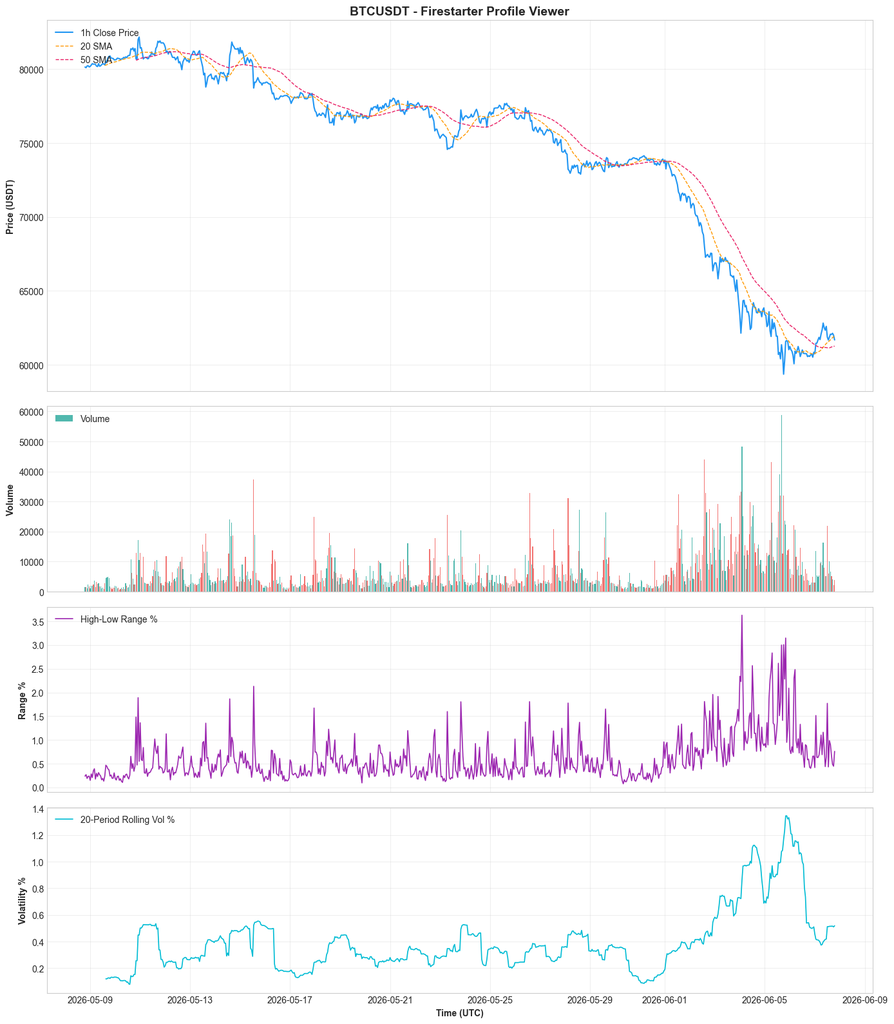

```python
# Compute price trend lines (SMAs)
df_1h['sma_20'] = df_1h['close'].rolling(20).mean()
df_1h['sma_50'] = df_1h['close'].rolling(50).mean()

# Volume colors: Green if close >= open (bullish), Red otherwise (bearish)
df_1h['vol_color'] = np.where(df_1h['close'] >= df_1h['open'], '#26a69a', '#ef5350')

# High-Low Candle spread %
df_1h['range_pct'] = ((df_1h['high'] - df_1h['low']) / df_1h['open']) * 100

# 20-period rolling volatility (standard deviation of log returns)
df_1h['log_ret'] = np.log(df_1h['close'] / df_1h['close'].shift(1))
df_1h['rolling_vol'] = df_1h['log_ret'].rolling(20).std() * 100

# Setup plot axes
fig, axes = plt.subplots(4, 1, figsize=(14, 16), sharex=True, gridspec_kw={'height_ratios': [2, 1, 1, 1]})

# Panel 1: Price and Trend
axes[0].plot(df_1h.index, df_1h['close'], color='#2196f3', linewidth=1.5, label='1h Close Price')
axes[0].plot(df_1h.index, df_1h['sma_20'], color='#ff9800', linewidth=1.0, linestyle='--', label='20 SMA')
axes[0].plot(df_1h.index, df_1h['sma_50'], color='#e91e63', linewidth=1.0, linestyle='--', label='50 SMA')
axes[0].set_ylabel('Price (USDT)', fontweight='bold')
axes[0].set_title(f'{SELECTED_SYMBOL} - Firestarter Profile Viewer', fontsize=14, fontweight='bold')
axes[0].legend(loc='upper left')
axes[0].grid(True, alpha=0.3)

# Panel 2: Color-Coded Volume
axes[1].bar(df_1h.index, df_1h['volume'], color=df_1h['vol_color'], width=0.03, alpha=0.8, label='Volume')
axes[1].set_ylabel('Volume', fontweight='bold')
axes[1].legend(loc='upper left')
axes[1].grid(True, alpha=0.3)

# Panel 3: High-Low Range %
axes[2].plot(df_1h.index, df_1h['range_pct'], color='#9c27b0', linewidth=1.2, label='High-Low Range %')
axes[2].set_ylabel('Range %', fontweight='bold')
axes[2].legend(loc='upper left')
axes[2].grid(True, alpha=0.3)

# Panel 4: Rolling Volatility %
axes[3].plot(df_1h.index, df_1h['rolling_vol'], color='#00bcd4', linewidth=1.2, label='20-Period Rolling Vol %')
axes[3].set_ylabel('Volatility %', fontweight='bold')
axes[3].set_xlabel('Time (UTC)', fontweight='bold')
axes[3].legend(loc='upper left')
axes[3].grid(True, alpha=0.3)

plt.tight_layout()
plt.show()
```